# Experimental Sociology - Week 03 - In Class

- Show All Code
- Hide All Code
- View Source

Analytical Methods: Ecological Models & Evolutionary Game Theory

Published

2025-04-23

# Open Questions

Besides the pre-class assignment?

# Problem 1

Modify Table 1, use $d=3$ instead of $d=2$.

Table 1: A $d$-repeated PD with two players and three strategies.

| $d=2$ | TFT | TFT-1 | aD |
| --- | --- | --- | --- |
| TFT | $4, 4$ | $1, \underline{5}$ | $-1, 3$ |
| TFT-1 | $\underline{5}, 1$ | $2, 2$ | $-1, \underline{3}$ |
| aD | $3,-1$ | $\underline{3},-1$ | $\underline{0}, \underline{0}$ |

## Solution

Table 2: A $d$-repeated PD with two players and three strategies.

| $d=3$ | TFT | TFT-1 | aD |
| --- | --- | --- | --- |
| TFT | $6, 6$ | $3, \underline{7}$ | $-1, 3$ |
| TFT-1 | $\underline{7}, 3$ | $4, 4$ | $-1, \underline{3}$ |
| aD | $3,-1$ | $\underline{3},-1$ | $\underline{0}, \underline{0}$ |

# Problem 2

Table 3: A fitness matrix with two strategies in a PD with TFT and aD, and $\delta=0.5$.

|  | TFT | aD |
| --- | --- | --- |
| TFT | $f_{TFT,TFT}=4$ | $f_{TFT,aD}=-1$ |
| aD | $f_{aD,TFT}=3$ | $f_{aD,aD}=0$ |

## Solution

$$F = \begin{pmatrix}
4 & -1 \\
3 & 0
\end{pmatrix}$$
Hence we must subtract 4 in the first column, and 0 in the second.

# Problem 3

## Subproblem 1

What is the problem if we want to translate the game Table 4 into fitness function

Table 4: Matching Pennies.

|  | Player 2: H ($p_2$) | Player 2: T ($1-p_2$) |
| --- | --- | --- |
| **Player 1: H** ($p_1$) | $\underline{1}, -1$ | $-1, \underline{1}$ |
| **Player 1: T** ($1-p_1$) | $-1, \underline{1}$ | $\underline{1}, -1$ |

### Solution

At first glance, the **Matching Pennies** game may appear symmetrical—but it is, in fact, **asymmetric**. Each player has the same set of strategies (H and T), but their payoffs are perfectly opposed: one player’s gain is the other’s loss. This zero-sum structure means **we can’t interpret the payoffs as fitness values** in an evolutionary setting, which typically assumes symmetric interactions within a single population.

## Subproblem 1

Translate the game Table 5 into a fitness function and show, that is has three evolutionary equilibria.

Table 5: Hawk-Dove-Game

|  | Player 2: Hawk | Player 2: Dove |
| --- | --- | --- |
| Player 1: Hawk | $1, 1$ | $4, 2$ |
| Player 1: Dove | $2, 4$ | $3, 3$ |

### Solution

Since this game is symmetrical, it directly translate into:

$$F = \begin{pmatrix}
1 & 4 \\
2 & 3
\end{pmatrix}$$

and normalize to:

$$F'=
\begin{pmatrix}
0 & 1 \\
1 & 0
\end{pmatrix}$$

Now, let $q=q_H$, then we have:

$$f_{\text{H}}(Q) = 0 \cdot q + 1 \cdot (1-q) = 1-q$$

$$f_{\text{D}}(Q) = 1 \cdot q + 0 \cdot (1-q) = q$$

Then the **average fitness** $\phi$ is:

$$\begin{align*}
\phi & = q \cdot f_{\text{H}}(Q) + (1 - q) \cdot f_{\text{D}}(Q) \\
& = q (1-q) + (1 - q)(q) \\
& = q- q^2 + q - q^2 \\
& = -2q^2+2q
\end{align*}$$
Again, we put this into the **replicator equation**:

$$\begin{align*}
\frac{dq}{dt} & = q \left( f_{\text{H}}(Q) - \phi \right) \\
& = q \left( (1-q) - (-2q^2+2q) \right) \\
& = q \left( 1-q + 2q^2-2q \right) \\
& = 2 q^3 -3 q^2 + q \\
\end{align*}$$

**Show R Code (Replicator Dynamic)**

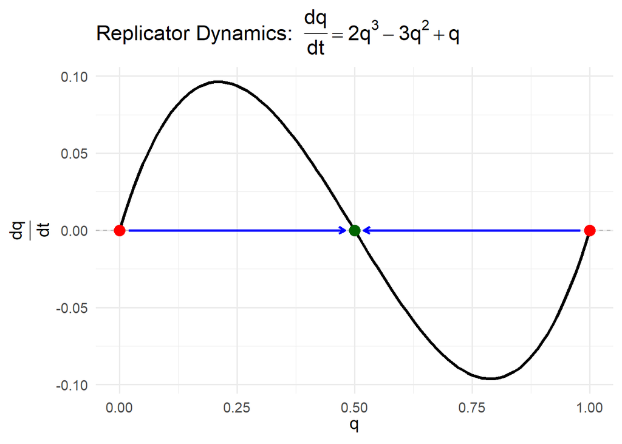

Figure 1: Replicator dynamics for two strategies (H and D).

```r
library(ggplot2)
library(grid)  # for arrow()

# Define the replicator function
replicator <- function(q) {
  2 * q^3 -3 * q^2 + q
}

# Create a sequence of q values between 0 and 1
q_vals <- seq(0, 1, length.out = 101)

# Compute the rate of change dq/dt
dq_dt <- replicator(q_vals)

# Create a data frame for plotting
df <- data.frame(q = q_vals, dq_dt = dq_dt)

# Plot
ggplot(df, aes(x = q, y = dq_dt)) +
  geom_line(color = "black", size = 1.2) +
  geom_hline(yintercept = 0, linetype = "dashed", color = "gray") +
  # Add equilibrium points
  geom_point(data = subset(df, abs(dq_dt) == 0 &  (q == 0 | q == 1)), aes(x = q, y = dq_dt), color = "red", size = 4) +
  geom_point(data = subset(df, abs(dq_dt) == 0 & !(q == 0 | q == 1)), aes(x = q, y = dq_dt), color = "darkgreen", size = 4) +
  # Add arrows from q = 0.5 toward 0 and toward 1
  annotate("segment", x = 0.02, y = 0, xend = 0.48, yend = 0,
               arrow = arrow(length = unit(0.2, "cm")), color = "blue", linewidth = 1) +
  annotate("segment", x = 0.98, y = 0, xend = 0.52, yend = 0,
               arrow = arrow(length = unit(0.2, "cm")), color = "blue", linewidth = 1) +
  labs(
    title = expression("Replicator Dynamics: " ~ frac(dq, dt) == 2 * q^3 -3 * q^2 + q),
    x = expression(q),
    y = expression(frac(dq, dt))
  ) +
  theme_minimal(base_size = 14)
```

Hence, we have two unstable evolutionary equilibria at the $Q=(1,0)$ and $Q=(0,1)$. The only stable evolutionary equilibrium is $Q=(0.5, 0.5)$.

# Problem 4

If you looked at https://ncase.me/trust/ under 5. “The evolution of distrust” Case shows that the number of rounds (in their case fixed numbers of rounds, but we will think of them as expected number of rounds) are crucial whether given the initial distribution of TFT or aD prevails in the end. This is because the number of rounds $d$ directly affect the fitness of both strategies. Model and analyze the replicator dynamics for $q=Q_{TFT}$ for the general case of $d$ rounds.

## Solution

Actually, it the payoff matrix looks like this:

Table 6: A fitness matrix with two strategies in a PD with TFT and aD, and $\delta=0.5$.

|  | TFT | aD |
| --- | --- | --- |
| TFT | $f_{TFT,TFT}=2d$ | $f_{TFT,aD}=-1$ |
| aD | $f_{aD,TFT}=3$ | $f_{aD,aD}=0$ |

So let’s directly normalize this payoff matrix:

$$F=
\begin{pmatrix}
0 & -1 \\
3-2d & 0
\end{pmatrix}$$

Now, let $q=q_{TFT}$, then we have:

$$f_{\text{TFT}}(Q) = - 1 \cdot (1 - q) = q - 1$$

$$f_{\text{aD}}(Q) = (3-2d) \cdot q = 3q - 2dq$$

Then the **average fitness** $\phi$ is:

$$\begin{align*}
\phi & = q \cdot f_{\text{TFT}}(Q) + (1 - q) \cdot f_{\text{aD}}(Q) \\
& = q \cdot (q - 1) + (1 - q) (3q - 2dq) \\
& = q^2 - q + 3q - 2dq -3q^2 + 2dq^2 \\
& = 2 d q^2 - 2 d q - 2 q^2 + 2 q \\
\end{align*}$$
Again, we put this into the **replicator equation**:

$$\begin{align*}
\frac{dq}{dt} & = q \left( f_{\text{TFT}}(Q) - \phi \right) \\
& = q \left( q - 1 - ( 2 d q^2 - 2 d q - 2 q^2 + 2 q) \right) \\
& = -2 d q^3 + 2 d q^2 + 2 q^3 - q^2 - q
\end{align*}$$

In the following we will use **polynomial division** to determine the the internal zero point. Let $f(q)$ the equation above, hence:

$$f(q) = (2 - 2d)q^3 + (2d - 1)q^2 - q$$

and we know that:

$$f(1) = 0$$
since the endpoints of a simplex are always a evolutionary equilibrium (i.e. if all are TFT). This implies that $(q - 1)$ is a factor of $f(q)$. So, we factor out $(q - 1)$ from $f(q)$:

Assume:

$$f(q) = (q - 1)(Aq^2 + Bq + C)$$

Expanding the right-hand side:

$$(q - 1)(Aq^2 + Bq + C) = Aq^3 + (B - A)q^2 + (C - B)q - C$$

Now match coefficients with the original expression:

$$f(q) = (2 - 2d)q^3 + (2d - 1)q^2 - q$$

From this, we find:

- $A = 2 - 2d$
- $B - A = 2d - 1$ $B - 2 + 2d = 2d -1$ $B = 1$
- $C - B = -1 \Rightarrow C = 0$

So the factorized form is:

$$f(q) = (q - 1)\left[(2 - 2d)q^2 + q\right]$$

To find the roots of $f(q)$, set it equal to zero:

$$(q - 1)\left[(2 - 2d)q^2 + q\right] = 0$$

This gives:

$$q = 1 \quad \text{or} \quad (2 - 2d)q^2 + q = 0$$

Fortunately, there is a simple [quadratic formula](https://en.wikipedia.org/wiki/Quadratic_equation) for $(2 - 2d)q^2 + q = 0$.

$$q^* = \frac{1}{2d-2}$$

Hence, the higher $d$ the lower the point $q^*$, where the unstable equilibrium is.

**Show R Code (Replicator Dynamic with flexibel d, shiny)**

```r
# app.R
library(shiny)
library(ggplot2)

# Define UI
ui <- fluidPage(
  titlePanel("Replicator Dynamics: TFT vs aD"),

  sidebarLayout(
    sidebarPanel(
      sliderInput("d",
                  "Number of expected rounds (d):",
                  min = 1,
                  max = 20,
                  value = 2,
                  step = 1)
    ),

    mainPanel(
      plotOutput("replicatorPlot", height = "500px"),
      helpText("This plot shows how the share of TFT strategy (q) changes over time for a given number of rounds d.
               Green dots indicate stable equilibria, while the red dot is unstable.")
    )
  )
)

# Define server logic
server <- function(input, output) {

  output$replicatorPlot <- renderPlot({

  # Replicator function with input$d
  replicator <- function(q, d) {
    -2 * d * q^3 + 2 * d * q^2 + 2 * q^3 - q^2 - q
  }

  # Compute q*
  q_star <- 1 / (2 * input$d - 2)

  q_vals <- seq(0, 1, length.out = 101)
  dq_dt <- replicator(q_vals, input$d)
  df <- data.frame(q = q_vals, dq_dt = dq_dt)

ggplot(df, aes(x = q, y = dq_dt)) +
  geom_line(color = "black", size = 1.2) +
  geom_hline(yintercept = 0, linetype = "dashed", color = "gray") +
  # Green dots at stable endpoints
  geom_point(data = subset(df, abs(dq_dt) < 1e-5 & (q == 0 | q == 1)),
             aes(x = q, y = dq_dt), color = "darkgreen", size = 4) +
  # Red dot at q* (interior unstable equilibrium)
  {
    if (q_star >= 0 && q_star <= 1)
      geom_point(aes(x = q_star, y = 0), color = "red", size = 4)
  } +
  # Optional: vertical line at q*
  {
    if (q_star >= 0 && q_star <= 1)
      geom_vline(xintercept = q_star, linetype = "dotted", color = "red")
  } +
  labs(
    title = bquote("Replicator Dynamics: " ~ frac(dq, dt) == f(q, delta == .(input$d))),
    subtitle = if (q_star >= 0 && q_star <= 1) {
      bquote("Unstable interior equilibrium at " ~ q^'*' ~ "=" ~ .(round(q_star, 3)))
    } else {
      "No interior equilibrium in [0, 1]"
    },
    x = expression(q),
    y = expression(frac(dq, dt))
  ) +
  theme_minimal(base_size = 14)

})

}

# Run the application
shinyApp(ui = ui, server = server)
```

# Problem 5

Show that aD and TFT are ESS, show that aC is not (only use this three strategies).

## Solution

We simply have to show that

1. $f_{ii} > f_{ji}$, or
2. $f_{ii} = f_{ji}$ and $f_{ij} > f_{jj}$.

holds. So let $d=2$, hence:

Table 7: A fitness matrix.

|  | TFT | aD | aC |
| --- | --- | --- | --- |
| TFT | $4$ | $-1$ | $4$ |
| aD | $3$ | $0$ | $6$ |
| aC | $4$ | $-2$ | $4$ |

Now we test each strategy.

### Is **TFT** an ESS?

- $$f_{\text{TFT,TFT}} = 4$$
- Compare with:
  - $$f_{\text{aD,TFT}} = 3 \Rightarrow 4 > 3$$
  - $$f_{\text{aC,TFT}} = 4 \Rightarrow 4 = 4$$
    , so check second condition:
    - $$f_{\text{TFT,aC}} = 4 > f_{\text{aC,aC}} = 4 \Rightarrow$$
      **not greater**, so second condition **not satisfied**

✅ TFT is **ESS against aD**,  
❌ but **not ESS against aC**.

So, **TFT is *not* an ESS overall**.

### Is **aD** an ESS?

- $$f_{\text{aD,aD}} = 0$$
- Compare with:
  - $$f_{\text{TFT,aD}} = -1 \Rightarrow 0 > -1$$
  - $$f_{\text{aC,aD}} = -2 \Rightarrow 0 > -2$$

✅ aD is **ESS against TFT**,  
✅ aD is **ESS against aC**,

### Is **aC** an ESS?

- $$f_{\text{aC,aC}} = 4$$
- Compare with:
  - $$f_{\text{TFT,aC}} = 4 \Rightarrow \text{equal} \Rightarrow$$
    check 2nd condition:
    - $$f_{\text{aC,TFT}} = 4$$
      ,
      $$f_{\text{TFT,TFT}} = 4 \Rightarrow$$
      **not greater**
  - $$f_{\text{aD,aC}} = 6 > 4 \Rightarrow$$
    **first condition fails**

❌ aC is **not ESS against TFT**,

❌ aC is **not ESS against aD**,

**Final Conclusion**

In this game:

- **aD is always ESS**
- **TFT is ESS against aD and simlar strategies, but not against cooperative strategies**
- **aC is never ESS**

# In-class projects

Let’s look at the **Matching Pennies** game at Table 4 again. Is there a way to model it with an evolutionary approach?

## Copyright

Copyright Sascha Grehl, 2025. All Rights Reserved